# LAGOS Spatial Analysis

Matthew Ross | Assignment completed by: George Woolsey

23 February, 2022

# LAGOS Analysis

## Loading in data

### First download and then specifically grab the locus (or site lat longs)

```r
# #Lagos download script

# LAGOSNE::lagosne_get(dest_folder = LAGOSNE:::lagos_path())

#Load in lagos
lagos <- lagosne_load()
names(lagos)

#Grab the lake centroid info
lake_centers <- lagos$locus
str(lake_centers)
```

### Convert to spatial data

```r
#Look at the column names
#names(lake_centers)

#Look at the structure
#str(lake_centers)

#View the full dataset
#View(lake_centers %>% slice(1:100))

spatial_lakes <- st_as_sf(lake_centers,coords=c('nhd_long','nhd_lat'),
                          crs=4326) %>% # EPSG:4326 = WGS 84
  st_transform(2163) # EPSG:2163 = US National Atlas Equal Area

#Subset for plotting
subset_spatial <- spatial_lakes %>%
  slice(1:100)

# subset_baser <- spatial_lakes[1:100,]

#Dynamic mapviewer
mapview(subset_spatial)
```

[interactive chart not shown]

### Subset to only Minnesota

```r
states <- us_states()

#Plot all the states to check if they loaded
#mapview(states)

minnesota <- states %>%
  filter(name == 'Minnesota') %>%
  st_transform(2163) # EPSG:2163 = US National Atlas Equal Area

#Subset lakes based on spatial position
minnesota_lakes <- spatial_lakes[minnesota,]

#Plotting the first 1000 lakes
minnesota_lakes %>%
  arrange(-lake_area_ha) %>%
    slice(1:1000) %>%
  mapview(.,zcol = 'lake_area_ha')
```

[interactive chart not shown]

# In-Class work

## Question 1)

Show a map outline of Iowa and Illinois (similar to Minnesota map upstream)

```r
#filter states dataset from USA USAboundaries us_states()
il_ia <- states %>%
  filter(name %in% c("Illinois", "Iowa")) %>%
  st_transform(2163) # EPSG:2163 = US National Atlas Equal Area

#see names of basemaps available to pass to "map.types" option below
# names(leaflet.providers::providers_loaded()$providers)

#make map
mapview(il_ia
        , zcol = "name"
        , legend = FALSE
        , col.regions = turbo(n= min(5, n_distinct(il_ia$name)))
        , alpha.regions = 0.5
        , map.types =  "OpenStreetMap"
        , label = c("stusps")
    )
```

[interactive chart not shown]

## Question 2)

Subset LAGOS data to these sites, how many sites are in Illinois and Iowa combined? How does this compare to Minnesota?

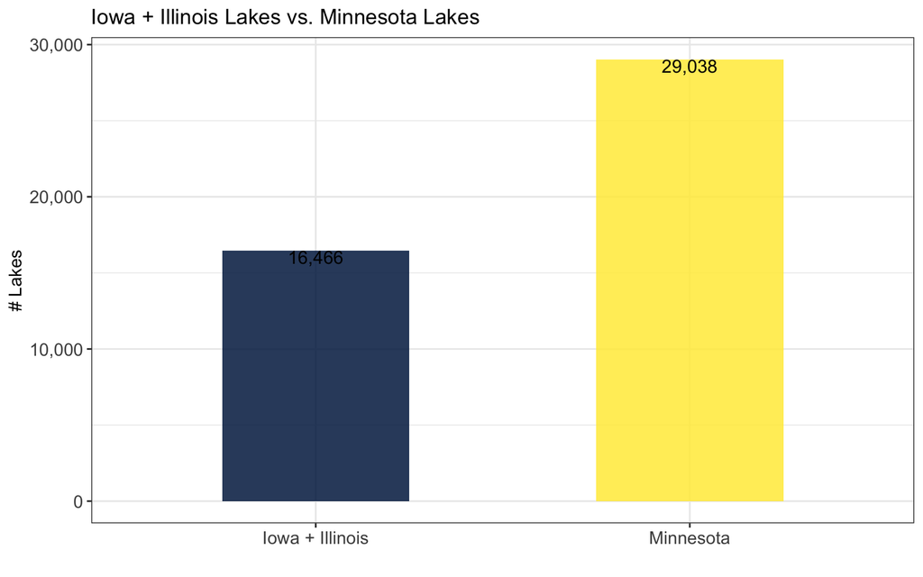

```r
#Subset lakes based on spatial position
il_ia_lakes <- spatial_lakes[il_ia,]

#create counts dataset
cnt_lakes <- c(
  n_distinct(il_ia_lakes$lagoslakeid)
  , n_distinct(minnesota_lakes$lagoslakeid)
)

st <- c("Iowa + Illinois", "Minnesota")

df <- data.frame(cnt_lakes, st)

#plot
ggplot(df, aes(x = st, y = cnt_lakes, fill = st)) +
  geom_col(alpha=0.85, width = 0.5) +
  geom_text(aes(label = scales::comma(cnt_lakes)), colour = "black", size = 4, vjust = "top") +
  scale_y_continuous(labels = label_comma()) +
  labs(
      title = "Iowa + Illinois Lakes vs. Minnesota Lakes"
    ) +
  xlab("") +
  ylab("# Lakes") +
  scale_fill_viridis(discrete = TRUE, option = "cividis") +
  theme_bw() +
  theme(
    legend.position="none"
    , axis.text.y = element_text(size = 11)
    , axis.text.x = element_text(size = 11)
  )
```

There are **16,466** lakes in Iowa and Illinois combined while Minnesota has **29,038** lakes. There are **12,572** more lakes in Minnesota than in Iowa and Illinois combined.

## Question 3)

What is the distribution of lake size in Iowa vs. Minnesota? Here I want to see a histogram plot with lake size on x-axis and frequency on y axis (check out geom_histogram)

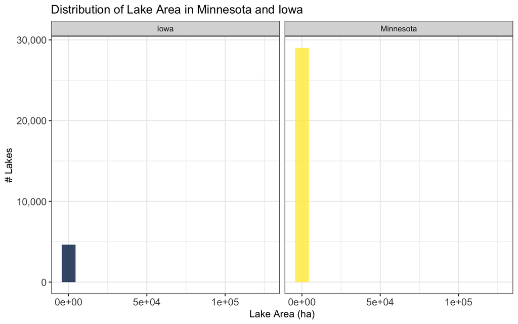

```r
# get Minnesota and Iowa polygons
mn_ia <- states %>%
  filter(name %in% c("Minnesota", "Iowa")) %>%
  st_transform(2163) # EPSG:2163 = US National Atlas Equal Area

# spatial join points to polygons
mn_ia_lakes <- st_join(spatial_lakes, mn_ia, left = FALSE)

# count lakes
# n_distinct(mn_ia_lakes$lagoslakeid)

#plot
ggplot(mn_ia_lakes, aes(lake_area_ha, fill = name)) +
  geom_histogram(bins = 15, alpha = 0.8) +
  facet_grid(. ~ name) +
  scale_y_continuous(labels = label_comma()) +
  labs(
      title = "Distribution of Lake Area in Minnesota and Iowa"
    ) +
  xlab("Lake Area (ha)") +
  ylab("# Lakes") +
  scale_fill_viridis(discrete = TRUE, option = "cividis") +
  theme_bw() +
  theme(
    legend.position="none"
    , axis.text.y = element_text(size = 11)
    , axis.text.x = element_text(size = 11)
  )
```

This histogram is not very informative due to outliers at the high end of lake area. Below is a quick solution to bin the top 5% of lakes based on area into their own bucket. In addition, to get a better comparison between states, we can use the `after_stat(density)` option to plot density on the y-axis instead of count.

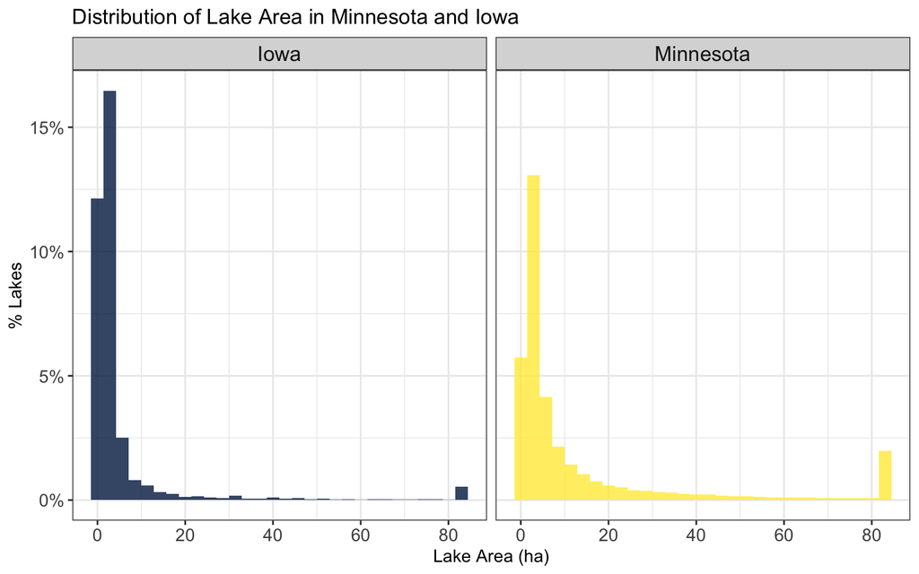

```r
# truncate top 5% of lakes in area into own bin
mn_ia_lakes <- mn_ia_lakes %>%
  mutate(lake_area_ha_trunc = ifelse(
      lake_area_ha >= quantile(mn_ia_lakes$lake_area_ha, 1-0.05)
      , quantile(mn_ia_lakes$lake_area_ha, 1-0.05)
      , lake_area_ha)
  )

# plot
ggplot(mn_ia_lakes, aes(lake_area_ha_trunc, after_stat(density), fill = name)) +
  geom_histogram(bins = 30, alpha = 0.8) +
  facet_grid(. ~ name) +
  scale_y_continuous(labels = label_percent(accuracy = 1)) +
  labs(
      title = "Distribution of Lake Area in Minnesota and Iowa"
    ) +
  xlab("Lake Area (ha)") +
  ylab("% Lakes") +
  scale_fill_viridis(discrete = TRUE, option = "cividis") +
  theme_bw() +
  theme(
    legend.position="none"
    , axis.text.y = element_text(size = 11)
    , axis.text.x = element_text(size = 11)
    , strip.text.x = element_text(size = 13)
  )
```

This histogram is more informative and allows us to see that Iowa has a higher propoertion of small lakes compared to Minnesota. There are many more large lakes (over **~84** ha) in Minnesota than in Iowa.

## Question 4)

Make an interactive plot of lakes in Iowa and Illinois and color them by lake area in hectares

```r
#sort lakes so that largest lakes are on bottom
il_ia_lakes_filter <- il_ia_lakes %>%
  arrange(-lake_area_ha) %>%
  slice(1:1000) %>%
  mutate(lake_area_ha_log = log10(lake_area_ha))

#point map
mapview(il_ia_lakes_filter
          , zcol = "lake_area_ha"
          , cex = "lake_area_ha_log"
          , alpha.regions = 0.5
          , map.types =  "OpenStreetMap"
          , label = c("gnis_name")
          , layer.name = "lake area (ha)"
          , popup = popupTable(
              il_ia_lakes_filter
              , zcol = c(
                "gnis_name"
                , "lake_area_ha"
                , "lagoslakeid"
              )
              , row.numbers = FALSE
              , feature.id = FALSE
            )
      )
```

[interactive chart not shown]

The interactive map of lakes is displaying only the largest 1000 lakes in Illinois and Iowa. Because there were **16,466** lakes in the two states, a filter is helpful in limiting the noise in the plot from too many points.

## Question 5)

What other data sources might we use to understand how reservoirs and natural lakes vary in size in these three states?

The r package [‘LAGOSNE’](https://cran.r-project.org/web/packages/LAGOSNE/LAGOSNE.pdf) aids users in accessing data from the [Lake Multi-Scaled Geospatial and Temporal Database](https://lagoslakes.org/). In addition to the `locus` dataset utilized above, the package also contains the `lakes_limno` dataset which includes measures of mean and maximum lake depth (meters). The package also makes the following datasets available:

* `chag` datasets contain information on climate, hydrology, atmospheric deposition, and surficial geology characteristics.

* `conn` datasets contain lake, stream, and wetland abundance and connectivity metrics.

* `lulc` datasets contain information on the land use and land cover (LULC) characteristics.

## Link to part 2

[Go to part 2](https://georgewoolsey.github.io/LAGOS_Spatial_Analyses/part2#Class_work)